# Ford GoBike System Data Exploration

## Preliminary Wrangling

This document explores a dataset containing information about individual rides made in a bike-sharing system covering the greater San Francisco Bay area.

```python
## import all packages and set plots to be embedded inline
import numpy as np
import pandas as pd
import matplotlib.pyplot as plt
import seaborn as sb
import math
import calendar

%matplotlib inline
```

```python
# load in the dataset into a pandas dataframe, print statistics
ride_bike = pd.read_csv('202007-baywheels-tripdata.csv')
```

```python
# high-level overview of data shape, composition and info
print(ride_bike.shape)
print(ride_bike.dtypes)
print(ride_bike.info())
ride_bike.head(10)
```

```
(154967, 13)
ride_id                object
rideable_type          object
started_at             object
ended_at               object
start_station_name     object
start_station_id      float64
end_station_name       object
end_station_id        float64
start_lat             float64
start_lng             float64
end_lat               float64
end_lng               float64
member_casual          object
dtype: object
<class 'pandas.core.frame.DataFrame'>
RangeIndex: 154967 entries, 0 to 154966
Data columns (total 13 columns):
 #   Column              Non-Null Count   Dtype
---  ------              --------------   -----
 0   ride_id             154967 non-null  object
 1   rideable_type       154967 non-null  object
 2   started_at          154967 non-null  object
 3   ended_at            154967 non-null  object
 4   start_station_name  102589 non-null  object
 5   start_station_id    102589 non-null  float64
 6   end_station_name    100407 non-null  object
 7   end_station_id      100407 non-null  float64
 8   start_lat           154967 non-null  float64
 9   start_lng           154967 non-null  float64
 10  end_lat             154771 non-null  float64
 11  end_lng             154771 non-null  float64
 12  member_casual       154967 non-null  object
dtypes: float64(6), object(7)
memory usage: 15.4+ MB
None
```

|  | ride_id | rideable_type | started_at | ended_at | start_station_name | start_station_id | end_station_name | end_station_id | start_lat | start_lng | end_lat | end_lng | member_casual |
| --- | --- | --- | --- | --- | --- | --- | --- | --- | --- | --- | --- | --- | --- |
| 0 | 68213B7BB2420043 | electric_bike | 2020-07-31 17:36:17 | 2020-07-31 17:48:13 | NaN | NaN | McAllister St at Baker St | 52.0 | 37.790000 | -122.460000 | 37.777414 | -122.441949 | casual |
| 1 | A64F0CD3A8E59529 | electric_bike | 2020-07-31 19:42:50 | 2020-07-31 19:49:54 | Buchanan St at North Point St | 400.0 | Buchanan St at North Point St | 400.0 | 37.804388 | -122.433510 | 37.804408 | -122.433509 | casual |
| 2 | B3690CA0F5179242 | electric_bike | 2020-07-31 17:18:46 | 2020-07-31 17:36:31 | NaN | NaN | Hyde St at Post St | 369.0 | 37.760000 | -122.410000 | 37.787422 | -122.416777 | casual |
| 3 | 162FFE2E157F4C8F | electric_bike | 2020-07-31 20:48:47 | 2020-07-31 21:05:04 | Jersey St at Castro St | 137.0 | NaN | NaN | 37.750576 | -122.433743 | 37.770000 | -122.420000 | casual |
| 4 | C5DA8100F428B934 | electric_bike | 2020-07-31 20:18:24 | 2020-07-31 20:24:26 | Market St at Steuart St | 16.0 | NaN | NaN | 37.794582 | -122.394791 | 37.790000 | -122.400000 | casual |
| 5 | E0C9A74ED3961210 | electric_bike | 2020-07-31 22:07:11 | 2020-07-31 22:13:09 | Newbury Park Dr at King Rd | 442.0 | NaN | NaN | 37.365589 | -121.867895 | 37.350000 | -121.880000 | casual |
| 6 | DABCDF2D3FD03474 | electric_bike | 2020-07-31 18:15:37 | 2020-07-31 18:33:11 | NaN | NaN | San Francisco Ferry Building (Harry Bridges Pl... | 15.0 | 37.800000 | -122.420000 | 37.795310 | -122.394190 | casual |
| 7 | 70A50F2CCD3A25CF | electric_bike | 2020-07-31 18:04:58 | 2020-07-31 18:08:25 | NaN | NaN | NaN | NaN | 37.740000 | -122.420000 | 37.740000 | -122.410000 | casual |
| 8 | 385534505B0034E7 | electric_bike | 2020-07-23 10:37:37 | 2020-07-23 10:54:20 | NaN | NaN | NaN | NaN | 37.760000 | -122.410000 | 37.780000 | -122.410000 | casual |
| 9 | 1E25D067C8E0B8E6 | electric_bike | 2020-07-23 11:14:41 | 2020-07-23 11:25:15 | NaN | NaN | NaN | NaN | 37.780000 | -122.410000 | 37.770000 | -122.420000 | casual |

```python
# value counts for qualitative variables
ride_bike['rideable_type'].value_counts(), ride_bike['member_casual'].value_counts(), ride_bike['start_station_name'].value_counts(), ride_bike['end_station_name'].value_counts()
```

```
(electric_bike    106031
 docked_bike       48936
 Name: rideable_type, dtype: int64,
 casual    92999
 member    61968
 Name: member_casual, dtype: int64,
 Market St at 10th St                            1476
 Powell St BART Station (Market St at 4th St)    1221
 Hyde St at Post St                              1120
 Fell St at Stanyan St                           1113
 4th St at 16th St                               1023
                                                 ...
 Alemany Blvd at Silver Ave                         6
 Foothill Blvd at Fruitvale Ave                     5
 Jerrold St at 3rd St                               4
 6th Ave at E 12th St (Temporary Location)          3
 San Antonio Park                                   3
 Name: start_station_name, Length: 426, dtype: int64,
 Market St at 10th St                            1434
 Powell St BART Station (Market St at 4th St)    1411
 Fell St at Stanyan St                           1178
 Mission Dolores Park                            1107
 4th St at Mission Bay Blvd S                    1046
                                                 ...
 6th Ave at E 12th St (Temporary Location)          5
 Foothill Blvd at Fruitvale Ave                     5
 16th St Depot                                      5
 San Jose Depot                                     5
 16th Depot Bike Fleet Station                      1
 Name: end_station_name, Length: 431, dtype: int64)
```

```python
# descriptive statistics for numeric variables
print(ride_bike[['start_lat', 'start_lng', 'end_lat', 'end_lng']].describe())
```

```
           start_lat      start_lng        end_lat        end_lng
count  154967.000000  154967.000000  154771.000000  154771.000000
mean       37.732393    -122.357516      37.732502    -122.353342
std         0.138354       0.167669       0.138407       0.599176
min        37.240000    -122.510000      37.230000    -122.510000
25%        37.760000    -122.433274      37.760000    -122.432532
50%        37.773981    -122.413233      37.773953    -122.412408
75%        37.788299    -122.391967      37.788472    -122.391984
max        37.880222    -121.770000      37.880222     -42.344893
```

- First of all we drop columns that we don't need and that at same time they also have null values
- On the other hand, we drop rows that has any null values.

```python
# We drop columns: 'start_station_name', 'start_station_id', 'end_station_name', 'end_station_id'
ride_bike.drop(['ride_id', 'start_station_name', 'start_station_id', 'end_station_name', 'end_station_id'], axis=1, inplace=True)
```

```python
# We check the changes
print(ride_bike.info())
ride_bike.head(1)
```

```
<class 'pandas.core.frame.DataFrame'>
RangeIndex: 154967 entries, 0 to 154966
Data columns (total 8 columns):
 #   Column         Non-Null Count   Dtype
---  ------         --------------   -----
 0   rideable_type  154967 non-null  object
 1   started_at     154967 non-null  object
 2   ended_at       154967 non-null  object
 3   start_lat      154967 non-null  float64
 4   start_lng      154967 non-null  float64
 5   end_lat        154771 non-null  float64
 6   end_lng        154771 non-null  float64
 7   member_casual  154967 non-null  object
dtypes: float64(4), object(4)
memory usage: 9.5+ MB
None
```

|  | rideable_type | started_at | ended_at | start_lat | start_lng | end_lat | end_lng | member_casual |
| --- | --- | --- | --- | --- | --- | --- | --- | --- |
| 0 | electric_bike | 2020-07-31 17:36:17 | 2020-07-31 17:48:13 | 37.79 | -122.46 | 37.777414 | -122.441949 | casual |

```python
# We drop rows with missing values
ride_bike.dropna(inplace=True)
```

```python
# We check the changes
ride_bike.info()
```

```
<class 'pandas.core.frame.DataFrame'>
Int64Index: 154771 entries, 0 to 154966
Data columns (total 8 columns):
 #   Column         Non-Null Count   Dtype
---  ------         --------------   -----
 0   rideable_type  154771 non-null  object
 1   started_at     154771 non-null  object
 2   ended_at       154771 non-null  object
 3   start_lat      154771 non-null  float64
 4   start_lng      154771 non-null  float64
 5   end_lat        154771 non-null  float64
 6   end_lng        154771 non-null  float64
 7   member_casual  154771 non-null  object
dtypes: float64(4), object(4)
memory usage: 10.6+ MB
```

We convert de object datatype of 'started_at' and 'ended_at' to Datetime to facilitate calculations later then we inspect the data with .describe.

```python
# We convert de object datatype of 'started_at' and 'ended_at' to Datetime.
ride_bike['started_at'] = pd.to_datetime(ride_bike['started_at'])
ride_bike['ended_at'] = pd.to_datetime(ride_bike['ended_at'])
```

```python
# We inspect the month and year with .describe()
ride_bike['started_at'].dt.day.describe(), ride_bike['started_at'].dt.month.describe(), ride_bike['started_at'].dt.year.describe()
```

```
(count    154771.000000
 mean         15.816917
 std           8.873864
 min           1.000000
 25%           8.000000
 50%          16.000000
 75%          24.000000
 max          31.000000
 Name: started_at, dtype: float64,
 count    154771.0
 mean          7.0
 std           0.0
 min           7.0
 25%           7.0
 50%           7.0
 75%           7.0
 max           7.0
 Name: started_at, dtype: float64,
 count    154771.0
 mean       2020.0
 std           0.0
 min        2020.0
 25%        2020.0
 50%        2020.0
 75%        2020.0
 max        2020.0
 Name: started_at, dtype: float64)
```

We create separate column for the week of the day (Monday, Twuesdat, Wednesday, Thursday, Friday, Saturday and Sunday), and forduration in minutes.

We notice that all the data is from July of 2020.

```python
# We create separate columns for day of the week, day, month, year and also we add and calculate another called 'duration'.
ride_bike['day_of_the_week'] = ride_bike['started_at'].dt.weekday.astype(str)
ride_bike['duration_min'] = ride_bike['ended_at'] - ride_bike['started_at']
ride_bike['duration_min'] = ride_bike['duration_min'].dt.seconds / 60

# We set the days of the weeks with their names instead of number.
ride_bike['day_of_the_week'] = ride_bike['day_of_the_week'].replace({'0': 'Monday'}, regex=True)
ride_bike['day_of_the_week'] = ride_bike['day_of_the_week'].replace({'1': 'Twuesday'}, regex=True)
ride_bike['day_of_the_week'] = ride_bike['day_of_the_week'].replace({'2': 'Wednesday'}, regex=True)
ride_bike['day_of_the_week'] = ride_bike['day_of_the_week'].replace({'3': 'Thursday'}, regex=True)
ride_bike['day_of_the_week'] = ride_bike['day_of_the_week'].replace({'4': 'Friday'}, regex=True)
ride_bike['day_of_the_week'] = ride_bike['day_of_the_week'].replace({'5': 'Saturday'}, regex=True)
ride_bike['day_of_the_week'] = ride_bike['day_of_the_week'].replace({'6': 'Sunday'}, regex=True)
```

```python
# We check the changes
print(ride_bike.dtypes)
ride_bike.head()
```

```
rideable_type              object
started_at         datetime64[ns]
ended_at           datetime64[ns]
start_lat                 float64
start_lng                 float64
end_lat                   float64
end_lng                   float64
member_casual              object
day_of_the_week            object
duration_min              float64
dtype: object
```

|  | rideable_type | started_at | ended_at | start_lat | start_lng | end_lat | end_lng | member_casual | day_of_the_week | duration_min |
| --- | --- | --- | --- | --- | --- | --- | --- | --- | --- | --- |
| 0 | electric_bike | 2020-07-31 17:36:17 | 2020-07-31 17:48:13 | 37.790000 | -122.460000 | 37.777414 | -122.441949 | casual | Friday | 11.933333 |
| 1 | electric_bike | 2020-07-31 19:42:50 | 2020-07-31 19:49:54 | 37.804388 | -122.433510 | 37.804408 | -122.433509 | casual | Friday | 7.066667 |
| 2 | electric_bike | 2020-07-31 17:18:46 | 2020-07-31 17:36:31 | 37.760000 | -122.410000 | 37.787422 | -122.416777 | casual | Friday | 17.750000 |
| 3 | electric_bike | 2020-07-31 20:48:47 | 2020-07-31 21:05:04 | 37.750576 | -122.433743 | 37.770000 | -122.420000 | casual | Friday | 16.283333 |
| 4 | electric_bike | 2020-07-31 20:18:24 | 2020-07-31 20:24:26 | 37.794582 | -122.394791 | 37.790000 | -122.400000 | casual | Friday | 6.033333 |

Also we create a column called 'total_km' when we calculate the total distance traveled between the difference of longitude ('end_lng' - 'start_lng') and latitude ('end_lat' - 'start_lat') in kilometers with haversine function. And later we drop the columns 'start_lat', 'start_lng', 'end_lat', 'end_lng' becasue now we don't need these.

```python
# We define haversine function
def haversine (lat1, lon1, lat2, lon2):
    rad = math.pi/180
    diff_lat = lat2 - lat1
    diff_lon = lon2 - lon1
    R = 6372.795477598
    a = (math.sin(rad*diff_lat/2))**2 + math.cos(rad*lat1) * math.cos(rad*lat2) * (math.sin(rad*diff_lon/2))**2
    distancia = 2*R*math.asin(math.sqrt(a))
    return distancia

# Now we are going to create a new column called 'total_dist' where we calculate the distance traveled.
distance_km = []
mesure = ride_bike.shape[0]
for x in range(mesure):
    lat1 = ride_bike.iloc[x, 3]
    lon1  = ride_bike.iloc[x, 4]
    lat2 = ride_bike.iloc[x, 5]
    lon2 = ride_bike.iloc[x, 6]
    distance = haversine(lat1, lon1 , lat2, lon2)
    distance_km.append(distance)
ride_bike['distance_km'] = distance_km

# Drop the columns 'start_lat', 'start_lng', 'end_lat', 'end_lng', we don't need its.
ride_bike = ride_bike.drop(['start_lat', 'start_lng', 'end_lat', 'end_lng'], axis=1)
```

```python
# Check the changes
print(ride_bike.shape)
print(ride_bike.info())
ride_bike.head()
```

```
(154771, 7)
<class 'pandas.core.frame.DataFrame'>
Int64Index: 154771 entries, 0 to 154966
Data columns (total 7 columns):
 #   Column           Non-Null Count   Dtype
---  ------           --------------   -----
 0   rideable_type    154771 non-null  object
 1   started_at       154771 non-null  datetime64[ns]
 2   ended_at         154771 non-null  datetime64[ns]
 3   member_casual    154771 non-null  object
 4   day_of_the_week  154771 non-null  object
 5   duration_min     154771 non-null  float64
 6   distance_km      154771 non-null  float64
dtypes: datetime64[ns](2), float64(2), object(3)
memory usage: 14.4+ MB
None
```

|  | rideable_type | started_at | ended_at | member_casual | day_of_the_week | duration_min | distance_km |
| --- | --- | --- | --- | --- | --- | --- | --- |
| 0 | electric_bike | 2020-07-31 17:36:17 | 2020-07-31 17:48:13 | casual | Friday | 11.933333 | 2.116073 |
| 1 | electric_bike | 2020-07-31 19:42:50 | 2020-07-31 19:49:54 | casual | Friday | 7.066667 | 0.002210 |
| 2 | electric_bike | 2020-07-31 17:18:46 | 2020-07-31 17:36:31 | casual | Friday | 17.750000 | 3.107746 |
| 3 | electric_bike | 2020-07-31 20:48:47 | 2020-07-31 21:05:04 | casual | Friday | 16.283333 | 2.475498 |
| 4 | electric_bike | 2020-07-31 20:18:24 | 2020-07-31 20:24:26 | casual | Friday | 6.033333 | 0.685065 |

### What is the structure of your dataset?

I perfomred the following operations on the original dataset:

- I dropped columns that we don't need which they also have at the same time null values, and we also dropped rows with null values.
- I change the type of the data of 'started_at' and 'ended_at' columns to Datetime to be able to get the data out.
- I added new columns for later visualizate the graphs and do proportions. This columns are the day of the week, the duration in minutes whuch is the difference beteen the 'started_at' and 'ended_at' columns, and the distance in kilometeres which has been calculted ith the Haversine function on 'start_lat', 'start_lng', 'end_lat' and 'end_lng' columns.

After clean, there are 154771 rides in the dataset with 7 features (rideable_type, started_at, ended_at, member_casual, day_of_the_week, duration_min, distance_km).

The variables rideable_type and member_casual are categorical with the following levels:

- rideable_type: electric_bike, docked_bike
- member_casual: member, casual
- day_of_the_week: Monday, Twuesday, Wednesday, Thursday, Friday, Saturday, Sunday

The variables 'started_at' and 'ended_at' are in Datetime for a better use.

The rest of variables how 'duration_min' and 'distance_km' are numeric.

### What is/are the main feature(s) of interest in your dataset?

I'm most interested in figuring out what features are best for predicting the follow questions:

- How long does the average trip take?
- When are most trips taken in dataset in terms of day of the week (Monday, Twuesday, Wednesday, Thursday, Friday, Saturday or Sunday). All the data taken is from July of 2020, the we don't need investigate nothing about month and year.
- The above depend on if a user is a member or costumer?

### What features in the dataset do you think will help support your investigation into your feature(s) of interest?

I expect that the variable 'duration_min' will be the most important for the investigation and I also expect that for more time of use greater distance travelled.

Just as importantly will be the variable 'started_at' for predicting when most trips is taken in terms of day of the week.

In addition to this, I think what the service will be more used by subscribers, and electrical bike than dicked bike.

## Univariate Exploration

UNIVARIATE EXPLORATION OF 'DURATION_MIN'

```python
# We use describe() for 'duration_min' column
ride_bike['duration_min'].describe()
```

```
count    154771.000000
mean         20.259112
std          43.936664
min           0.000000
25%           7.333333
50%          12.950000
75%          22.600000
max        1439.983333
Name: duration_min, dtype: float64
```

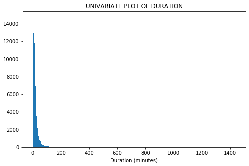

```python
# Start with a standard-scaled plot of 'duration_min'
binsize = 2
bins = np.arange(0, ride_bike['duration_min'].max()+binsize, binsize)

plt.figure(figsize=[8, 5])
plt.hist(data = ride_bike, x = 'duration_min', bins = bins)
plt.xlabel('Duration (minutes)')
plt.title('UNIVARIATE PLOT OF DURATION')
plt.show()
```

There's a very long piece of almost flat line so let's scale the x-axis in two ways, first with pyplot xlim function and second we with pyplot xscale function.

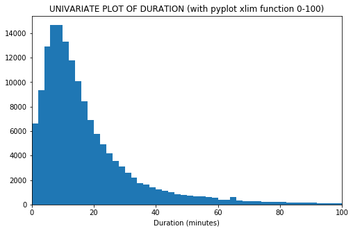

```python
# Plot hist of 'duration_min' with xlim (0, 100)
binsize = 2
bins = np.arange(0, ride_bike['duration_min'].max()+binsize, binsize)

# We plot histogram with pyplot slim function cause we have much outlier above 100 more or less
plt.figure(figsize=[8, 5])
plt.hist(data = ride_bike, x = 'duration_min', bins = bins)
plt.xlim(0, 100)
plt.xlabel('Duration (minutes)')
plt.title('UNIVARIATE PLOT OF DURATION (with pyplot xlim function 0-100)')
plt.show()
```

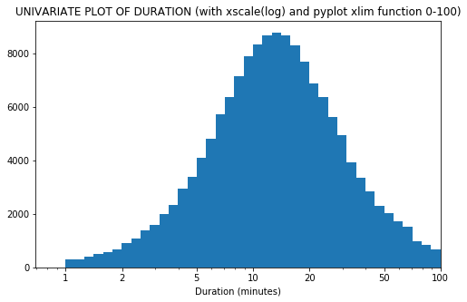

```python
# Plot hist of 'duration_min' with xscale('log') and pyplot xlim function between 0 and 100
binsize = 0.05
bins = 10 ** np.arange(0, np.log10(ride_bike['duration_min'].max())+binsize, binsize)

# We plot histogram with pyplot log function
plt.figure(figsize=[8, 5])
plt.hist(data = ride_bike, x = 'duration_min', bins = bins)
plt.xscale('log')
plt.xlim(0, 100)
plt.xlabel('Duration (minutes)')
plt.title('UNIVARIATE PLOT OF DURATION (with xscale(log) and pyplot xlim function 0-100)')
ticks_locs = [1, 2, 5, 10, 20, 50, 100]
plt.xticks(ticks_locs, ticks_locs)
plt.show()
```

> `We observe that the distribution seems unimodal. We have a big peak of quantity of bike rides with very short duration, about 12 minutes more or less.

UNIVARIATE EXPLORATION OF 'DISTANCE_KM' COLUMN.

```python
# We use describe() for 'distance_km' column
ride_bike['distance_km'].describe()
```

```
count    154771.000000
mean          2.414869
std          48.912061
min           0.000000
25%           0.879573
50%           1.751791
75%           2.890094
max        6802.621566
Name: distance_km, dtype: float64
```

```python
print(ride_bike.query("distance_km > 17").count())
print(ride_bike.query("distance_km > 17").min())
```

```
rideable_type      10
started_at         10
ended_at           10
member_casual      10
day_of_the_week    10
duration_min       10
distance_km        10
dtype: int64
rideable_type              docked_bike
started_at         2020-07-10 11:45:03
ended_at           2020-07-10 12:59:52
member_casual                   casual
day_of_the_week                 Friday
duration_min                      4.25
distance_km                    17.4896
dtype: object
```

```python
print(ride_bike.query("distance_km > 18").count())
print(ride_bike.query("distance_km > 18").min())
```

```
rideable_type      8
started_at         8
ended_at           8
member_casual      8
day_of_the_week    8
duration_min       8
distance_km        8
dtype: int64
rideable_type              docked_bike
started_at         2020-07-27 20:32:23
ended_at           2020-07-27 20:42:23
member_casual                   casual
day_of_the_week                 Friday
duration_min                      4.25
distance_km                    6800.64
dtype: object
```

We notice que for a greater distances than 18 we have 8 entries that have a distance trveled greater than 6800 km which is impossible, so we plot a histogram of distance_km with pyplot xlim function between 0 and 18.

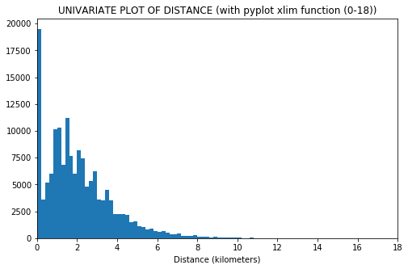

```python
# Histogram of 'distance_km' with pyplot xlim function beteen 0 and 18
binsize = 0.2
bins = np.arange(0, ride_bike['distance_km'].max()+binsize, binsize)

# We plot histogram with pyplot xlim function cause we have 8 outliers above 18 km of distance
plt.figure(figsize=[8, 5])
plt.xlim(0, 18)
plt.hist(data = ride_bike, x = 'distance_km', bins = bins)
plt.xlabel('Distance (kilometers)')
plt.title('UNIVARIATE PLOT OF DISTANCE (with pyplot xlim function (0-18))')
plt.show()
```

> `We observe in the same way that we have very few entries respectively the total of the data with a greater duration of 10 km, so we are going to plot with a pyplot xlim function between 0 and 10 for a btter visualization of the distribution.`

```python
print(ride_bike.query("distance_km > 10").count())
print(ride_bike.query("distance_km > 10").min())
```

```
rideable_type      159
started_at         159
ended_at           159
member_casual      159
day_of_the_week    159
duration_min       159
distance_km        159
dtype: int64
rideable_type              docked_bike
started_at         2020-07-01 13:45:46
ended_at           2020-07-01 14:26:10
member_casual                   casual
day_of_the_week                 Friday
duration_min                      4.25
distance_km                     10.002
dtype: object
```

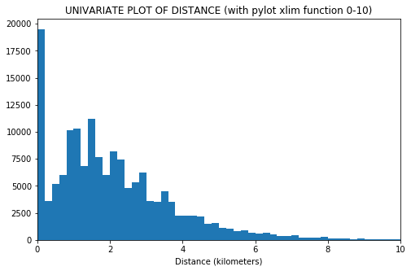

```python
# Histogram of 'distance_km' with pyplot xlim function beteen 0 and 10
binsize = 0.2
bins = np.arange(0, ride_bike['distance_km'].max()+binsize, binsize)

# We plot histogram with pyplot xlim function cause we have 159 outliers greater than 10 km of distance
plt.figure(figsize=[8, 5])
plt.xlim(0, 10)
plt.hist(data = ride_bike, x = 'distance_km', bins = bins)
plt.xlabel('Distance (kilometers)')
plt.title('UNIVARIATE PLOT OF DISTANCE (with pylot xlim function 0-10)')
plt.show()
```

> `We observe that we have a very high peak in the amount of bike rides with very short distances of approximately less than 200 meters and another high peak although less high with distances between 1 and two kilometers. We also observe that we hardly have bike rides above 10 km of distance.`

UNIVARIATE PLOT FOR THE REST OF VARIABLES OF INTEREST

The rest of variables of our interest are:

- Bike type (electric bike or docked bike)
- Customer type (member or casual)
- Hour of the day
- Day of the month
- Day_of_the week (Monday, Twuesday, Wednesday, Thursday, Friday, Saturday and Sunday)

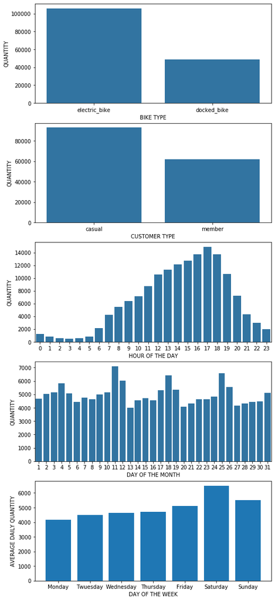

```python
# let's plot all five together to get an idea of each ordinal variable's distribution.
plt.subplots(nrows=5, figsize = [8,20])

# Plot
base_color = sb.color_palette()[0]

plt.title('BAR CHART OF ORDINAL VARIABLES')

plt.subplot(5,1,1)
sb.countplot(data = ride_bike, x = 'rideable_type', color = base_color)
plt.xlabel('BIKE TYPE')
plt.ylabel('QUANTITY')

plt.subplot(5,1,2)
sb.countplot(data = ride_bike, x = 'member_casual', color = base_color)
plt.xlabel('CUSTOMER TYPE')
plt.ylabel('QUANTITY')

plt.subplot(5,1,3)
sb.countplot(ride_bike['started_at'].dt.hour, color = base_color)
plt.xlabel('HOUR OF THE DAY')
plt.ylabel('QUANTITY')

plt.subplot(5,1,4)
sb.countplot(ride_bike['started_at'].dt.day, color=base_color)
plt.xlabel('DAY OF THE MONTH')
plt.ylabel('QUANTITY')

# We calculate the last plot with proportions for day of day_of_the_week because in July of 2020 we have 4 days for Monday,
# Twuesday, Saturday and Sunday, and 5 days for Wednesday, Thursday and Friday
plt.subplot(5,1,5)
week_order = ['Monday', 'Twuesday', 'Wednesday', 'Thursday', 'Friday', 'Saturday', 'Sunday']
Monday = ride_bike[ride_bike['day_of_the_week'] == 'Monday']['day_of_the_week'].count() / 4
Twesday = ride_bike[ride_bike['day_of_the_week'] == 'Twuesday']['day_of_the_week'].count() / 4
Wednesday = ride_bike[ride_bike['day_of_the_week'] == 'Wednesday']['day_of_the_week'].count() / 5
Thursday = ride_bike[ride_bike['day_of_the_week'] == 'Thursday']['day_of_the_week'].count() / 5
Friday = ride_bike[ride_bike['day_of_the_week'] == 'Friday']['day_of_the_week'].count() / 5
Saturday = ride_bike[ride_bike['day_of_the_week'] == 'Saturday']['day_of_the_week'].count() / 4
Sunday = ride_bike[ride_bike['day_of_the_week'] == 'Sunday']['day_of_the_week'].count() / 4
heights = [Monday, Twesday, Wednesday, Thursday, Friday, Saturday, Sunday]
plt.bar(week_order, heights)
plt.xlabel('DAY OF THE WEEK')
plt.ylabel('AVERAGE DAILY QUANTITY')

plt.show()
```

> - **`rideable_type`:** We observe that more or less twice as many electric bikes were used compared to docked bikes.
> - **`member_Casual`:** We observe that the majority of clients are casual with 50% more than subscribed clients
> - **`hour of the day`:** We observe that the rush hour is at 5 pm and the majority of ride bikes is between the 7 am and 9 pm.
> - **`day of the month`:** We observe peaks in each weekend.
> - **`day of the week`:** We bserve that the majority of ride bikes are in Saturday and in second place in Sunday, followin of Friday. During the week there are fewer amounts of bike rides and follows a slightly ascending line from Monday to Friday

Calculates the proportion of the largest number of types of users which is casual

```python
# Calculates the proportion of the largest number of types of users which is casual
prop_casual = ride_bike.query("member_casual == 'casual'")['member_casual'].count() / ride_bike['member_casual'].shape[0]
prop_member = ride_bike.query("member_casual == 'member'")['member_casual'].count() / ride_bike['member_casual'].shape[0]
print('PROPORTION OF CUTOMER TYPES')
print('The proportion of casual customers is: ', prop_casual)
print('The proportion of member customers is: ', prop_member)
```

```
PROPORTION OF CUTOMER TYPES
The proportion of casual customers is:  0.6000284290984745
The proportion of member customers is:  0.39997157090152546
```

Calculates the proportion of the largest number of types of bikes which is electric bike

```python
# Calculates the proportion of the largest number of types of bikes which is electric bike
prop_electric = ride_bike.query("rideable_type == 'electric_bike'")['rideable_type'].count() / ride_bike['rideable_type'].shape[0]
prop_docked = ride_bike.query("rideable_type == 'docked_bike'")['rideable_type'].count() / ride_bike['rideable_type'].shape[0]
print('PROPORTION OF BIKE TYPES')
print('The proportion of electric bikes is: ', prop_electric)
print('The proportion of docked bickes is: ', prop_docked)
```

```
PROPORTION OF BIKE TYPES
The proportion of electric bikes is:  0.6850831228072443
The proportion of docked bickes is:  0.31491687719275574
```

### Of the features you investigated, were there any unusual distributions? Did you perform any operations on the data to tidy, adjust, or change the form of the data? If so, why did you do this?

When investingating the distance_km variable, we also notice that we have a large range of values andwe have a few ouliers who unbalance the graph, so we do a scale-plot with pyplot xlim function in the x axis.

I perfomred the following operations on the data:

- I needed to change the scale of the plot of the data because in any variables of interest we have a lot of records in the x axis and we have few utliers that unbalance the graph and prevent its correct vision of the data.
- I needed to calculate in array the proporiton of record for the day of the week because in July of 2020 we have 4 days for Monday, Twuesday, Saturdat and Sunday, and 5 days for Wednesday, Thirsday and Friday, which unbalances the proportions.

## Bivariate Exploration

To start off with, I want to look at the pairwise correlations present between features in the data.

```python
duration_distance = ['duration_min', 'distance_km']
```

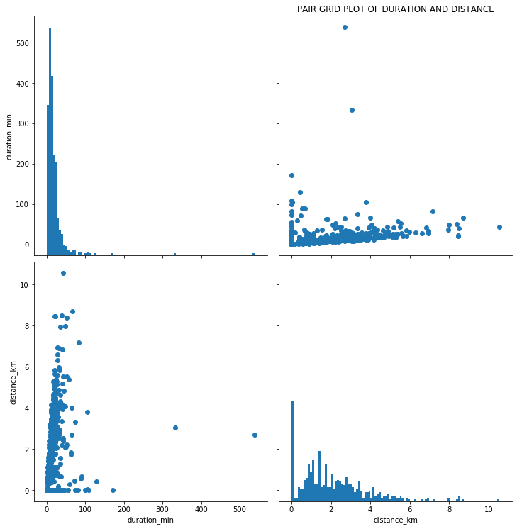

```python
# plot matrix: sample 500 rides so that plots are clearer and they render faster
samples = np.random.choice(ride_bike.shape[0], 500, replace = False)
ride_bike_samp = ride_bike.loc[samples, :]

g = sb.PairGrid(data = ride_bike_samp, vars = duration_distance, size=5)
g = g.map_diag(plt.hist, bins = 100);
g.map_offdiag(plt.scatter)
plt.title('PAIR GRID PLOT OF DURATION AND DISTANCE');
```

> `In this sample plots we observe that there is a relationship of pistive increase between duration and distance, the line of which increases strongly in the relationship between duration vs. distance up to approximately 50 minutes and slightly in the relationship between distance and duration up to 6 km.`

As expected, the 'duration_min' and 'distance_km' columns are correlated. because the longer the duration of the trip the more distance you has traveled.

Now, I are going to do a scatterplot and heatmap between both variables to go into more detail.

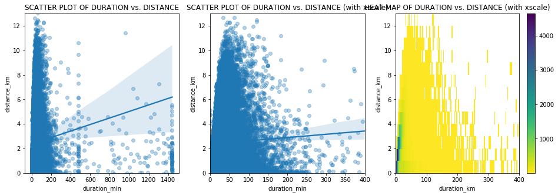

```python
# Scatterplot with Seaborn Regplot for duration_min and distance_km
plt.figure(figsize = [16, 5])

plt.subplot(1,3,1)
sb.regplot(data = ride_bike, x = 'duration_min', y = 'distance_km', x_jitter = 0.2, y_jitter = 0.2, scatter_kws = {'alpha' : 1/3})
plt.ylim(0, 13)
plt.title('SCATTER PLOT OF DURATION vs. DISTANCE');

plt.subplot(1,3,2)
sb.regplot(data = ride_bike, x = 'duration_min', y = 'distance_km', x_jitter = 0.2, y_jitter = 0.2, scatter_kws = {'alpha' : 1/3})
plt.xlim(0, 400)
plt.ylim(0, 13)
plt.title('SCATTER PLOT OF DURATION vs. DISTANCE (with xscale)');

plt.subplot(1,3,3)
bins_x = np.arange(0, 400+1, 1)
bins_y = np.arange(0, 13+1, 1)
plt.hist2d(data = ride_bike, x = 'duration_min', y = 'distance_km', bins = [bins_x, bins_y], cmap = 'viridis_r', cmin = 0.2)
plt.colorbar()
plt.xlabel('duration_km')
plt.ylabel('distance_km')
plt.title('HEAT MAP OF DURATION vs. DISTANCE (with xscale)');
```

> `In this plots we can check that most of the bike rides are between 0 and 150 minutes and there are an ascending correlation line of distance traveled until reaching the duration about 50 minutes and the comes down, so there are a peak in durations of 50 minutes ith a distance travaled of about 11 km.`

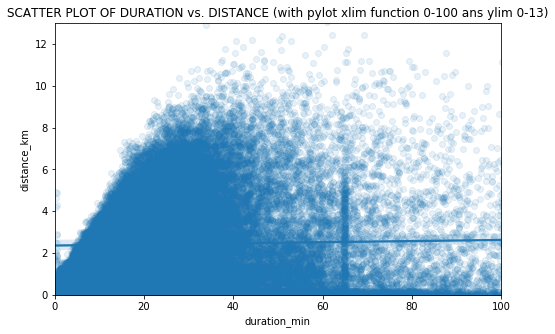

```python
# We do a pyplot xlim function between 0 and 100 for a better visualization of the distribution
plt.figure(figsize = [8, 5])

sb.regplot(data = ride_bike, x = 'duration_min', y = 'distance_km', x_jitter = 0.2, y_jitter = 0.2, scatter_kws = {'alpha' : 1/10})
plt.xlim(0, 100)
plt.ylim(0, 13)
plt.title('SCATTER PLOT OF DURATION vs. DISTANCE (with pylot xlim function 0-100 ans ylim 0-13)');
```

> `With more scale on the x-axis we can see that the data are similar but change a little, we hve a peak for durations between 30 and 45 minutes more or les with a maximum distance traveled of 8 km in the majority of the bike rides.`

I do a countplot for categorical variables 'member_casual' and 'rideable_type' for seeing the proportions between both variables.

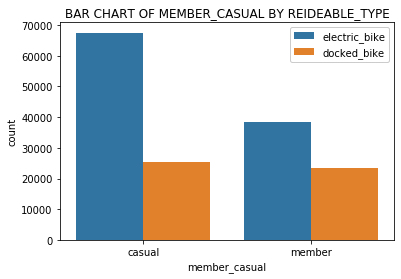

```python
# plotting
ax = sb.countplot(data = ride_bike, x = 'member_casual', hue = 'rideable_type')
ax.legend(loc = 1, framealpha = 1) # lower right, no transparency
plt.title('BAR CHART OF MEMBER_CASUAL BY REIDEABLE_TYPE');
```

> `We cannot draw any relational conclusions but it can be said that there is practically a greater use of electric bicycles regardless of the type of customer.`

```python
# Calculates the proportion of the largest number of bikes of users which is electric_bike for each customer type (member or casual)
prop_electrical_casual = ride_bike.query("member_casual == 'casual' and rideable_type == 'electric_bike'")['rideable_type'].count() / ride_bike.query("member_casual == 'casual'").shape[0]
prop_electrical_member = ride_bike.query("member_casual == 'member' and rideable_type == 'electric_bike'")['rideable_type'].count() / ride_bike.query("member_casual == 'member'").shape[0]
prop_docked_casual = ride_bike.query("member_casual == 'casual' and rideable_type == 'docked_bike'")['rideable_type'].count() / ride_bike.query("member_casual == 'casual'").shape[0]
prop_docked_member = ride_bike.query("member_casual == 'member' and rideable_type == 'docked_bike'")['rideable_type'].count() / ride_bike.query("member_casual == 'member'").shape[0]
print('PROPORTION OF BIKE TYPE FOR CASUAL CUSTOMERS')
print('The proportion of electrical bikes for casual customers is: ', prop_electrical_casual)
print('The proportion of docked bikes for casual customers is: ', prop_docked_casual)
print('-------------------------------------------------------------------------------')
print('PROPORTION OF BIKE TYPE FOR MEMBER CUSTOMERS')
print('The proportion of electrical bikes for member customers is: ', prop_electrical_member)
print('The proportion of docked bikes for member customers is: ', prop_docked_member)
```

```
PROPORTION OF BIKE TYPE FOR CASUAL CUSTOMERS
The proportion of electrical bikes for casual customers is:  0.7266736300300429
The proportion of docked bikes for casual customers is:  0.273326369969957
-------------------------------------------------------------------------------
PROPORTION OF BIKE TYPE FOR MEMBER CUSTOMERS
The proportion of electrical bikes for member customers is:  0.6226899715688808
The proportion of docked bikes for member customers is:  0.37731002843111916
```

I do two countplots :

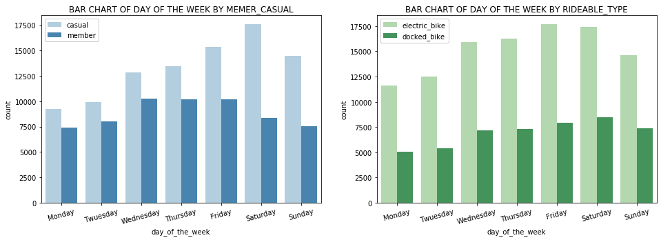

```python
# plotting
plt.figure(figsize = [16, 5])


plt.subplot(1,2,1)
plt.title('BAR CHART OF DAY OF THE WEEK BY MEMER_CASUAL');
week_order = ['Monday', 'Twuesday', 'Wednesday', 'Thursday', 'Friday', 'Saturday', 'Sunday'];
ax = sb.countplot(data = ride_bike, x = 'day_of_the_week', hue = 'member_casual', order = week_order, palette = 'Blues');
ax.legend(loc = 2, framealpha = 1); # lower right, no transparency
plt.xticks(rotation = 15);

plt.subplot(1,2,2)
plt.title('BAR CHART OF DAY OF THE WEEK BY RIDEABLE_TYPE');
week_order = ['Monday', 'Twuesday', 'Wednesday', 'Thursday', 'Friday', 'Saturday', 'Sunday'];
ax = sb.countplot(data = ride_bike, x = 'day_of_the_week', hue = 'rideable_type', order = week_order, palette = 'Greens');
ax.legend(loc = 2, framealpha = 1); # lower right, no transparency
plt.xticks(rotation = 15);
```

> `In this plot we observe that in general lines we have more or less 50% more than casual type customers compared to subscribed and 100% more electric bicycles compared to docked bikes. The amount of the number of records in reference to the day of the week is distorted because in that month we have 5 days that are Wednesday, Thursday and Friday with respect to Monday, Tuesday, Saturday and Sunday that are 4 days in total.`

I do the same for 'day' column.

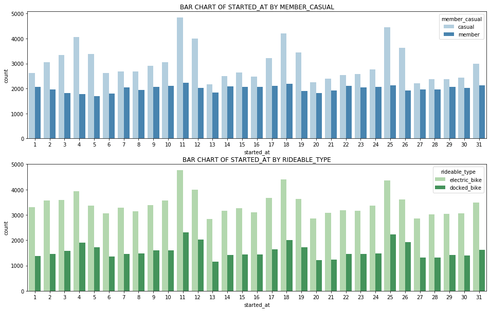

```python
plt.figure(figsize = [16, 10])
day = ride_bike['started_at'].dt.day

plt.subplot(2,1,1)
plt.title('BAR CHART OF STARTED_AT BY MEMBER_CASUAL');
sb.countplot(ride_bike['started_at'].dt.day, hue = ride_bike['member_casual'], palette = 'Blues');

plt.subplot(2,1,2)
sb.countplot(ride_bike['started_at'].dt.day, hue = ride_bike['rideable_type'], palette = 'Greens');
plt.title('BAR CHART OF STARTED_AT BY RIDEABLE_TYPE');
```

> `In this plot we also observe the same relationship the quantity of customer types and bike types, how e mentioned before e have a peaks with higher ride bikes in the days that are weekend.`

### Talk about some of the relationships you observed in this part of the investigation. How did the feature(s) of interest vary with other features in the dataset?

As expected, the 'duration_min' and 'distance_km' columns are correlated. because the longer the duration of the trip the more distance you has traveled.!

### Did you observe any interesting relationships between the other features (not the main feature(s) of interest)?

The proportion of electrical bikes for casual customers is 73% and 27% of docked bikes. For member customers we have a 62% of electrical bike and 38% of docked bike, so it seems that the type of customer is not correlated with the type of bike.

Also we don't have correlation beteen customer type and rideabñe type becasue the distribuiton in their plots are a little bit diffetent.

## Multivariate Exploration

> Create plots of three or more variables to investigate your data even further. Make sure that your investigations are justified, and follow from your work in the previous sections.

I do a scatterd-plot between duration and distance based on the type of costumer. I scaled the y axis with ylim because we have a few outliers that unbalance the plot.

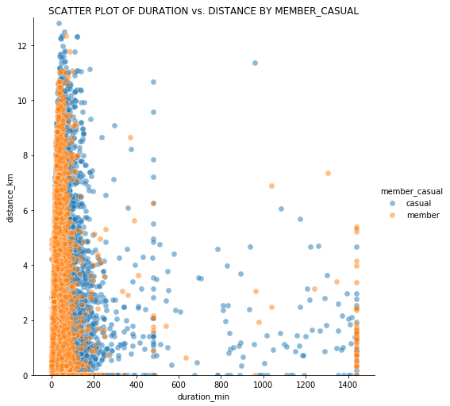

```python
kws = dict(s=50, linewidth=.5, edgecolor="w")
g = sb.FacetGrid(data = ride_bike, hue = 'member_casual',  size = 7);
g.map(plt.scatter, 'duration_min', 'distance_km', alpha=0.5, **kws);
g.add_legend()
plt.title('SCATTER PLOT OF DURATION vs. DISTANCE BY MEMBER_CASUAL');
plt.ylim(0, 13);
```

I also do scaled xlim for major clarity in the distribution of the plot.

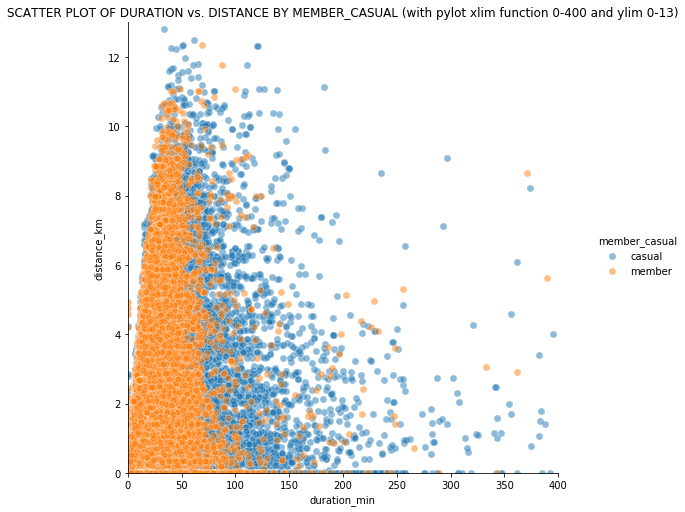

```python
kws = dict(s=50, linewidth=.5, edgecolor="w")
g = sb.FacetGrid(data = ride_bike, hue = 'member_casual', size = 7);
g.map(plt.scatter, 'duration_min', 'distance_km', alpha=0.5, **kws);
g.add_legend()
plt.xlim(0, 400);
plt.ylim(0, 13);
plt.title('SCATTER PLOT OF DURATION vs. DISTANCE BY MEMBER_CASUAL (with pylot xlim function 0-400 and ylim 0-13)');
```

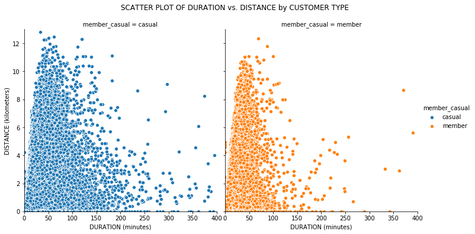

```python
g = sb.FacetGrid(ride_bike, col="member_casual", hue='member_casual', size=5);
g.map_dataframe(sb.scatterplot, x="duration_min", y="distance_km");
plt.xlim(0, 400);
plt.ylim(0, 13);
g.fig.suptitle('SCATTER PLOT OF DURATION vs. DISTANCE by CUSTOMER TYPE', y=1.05);
g.add_legend()
g.set_axis_labels("DURATION (minutes)", "DISTANCE (kilometers)");
```

> `In this plot we observe that the type of client hardly interferes in the relationship between the duration of the bicycle ride and the distance traveled following more or less the same pattern, but would tell although with a greater number of rides for casual clients because they are the ones who use the service the most`

I do same based on bike type.

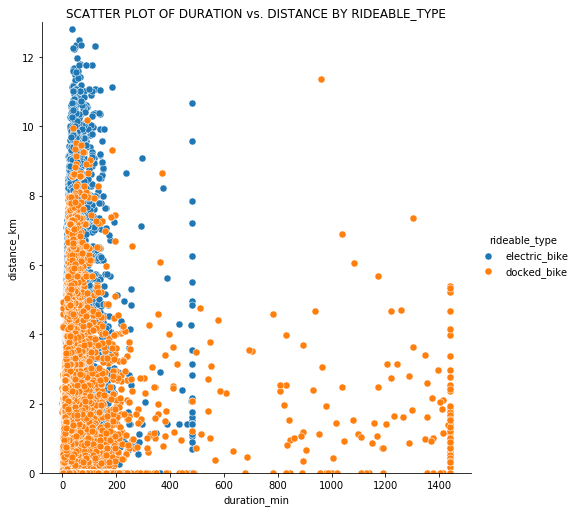

```python
kws = dict(s=50, linewidth=.5, edgecolor="w")
g = sb.FacetGrid(data = ride_bike, hue = 'rideable_type', size = 7);
g.map(plt.scatter, 'duration_min', 'distance_km', **kws);
g.add_legend();
plt.ylim(0, 13);
plt.title('SCATTER PLOT OF DURATION vs. DISTANCE BY RIDEABLE_TYPE');
```

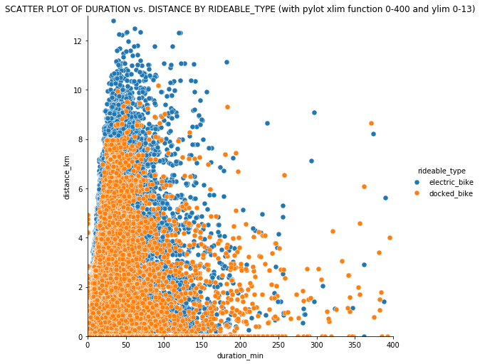

```python
kws = dict(s=50, linewidth=.5, edgecolor="w")
g = sb.FacetGrid(data = ride_bike, hue = 'rideable_type', size = 7)
g.map(plt.scatter, 'duration_min', 'distance_km', **kws)
g.add_legend()
plt.xlim(0, 400);
plt.ylim(0, 13);
plt.title('SCATTER PLOT OF DURATION vs. DISTANCE BY RIDEABLE_TYPE (with pylot xlim function 0-400 and ylim 0-13)');
```

> `In this plot we observe that the type of bike hardly interferes very litle in the relationship between the duration of the bicycle ride and the distance traveled with a maxium distance traveled for durations about 40 minutes for electric biked and a maxium distance traveled about 11 km for a durations about 50 minutes too, although there seems to be a greater number of bije rides using electric bike.`

Now I plot the correlation between the duration and distance of the trip as customer type and bike type.

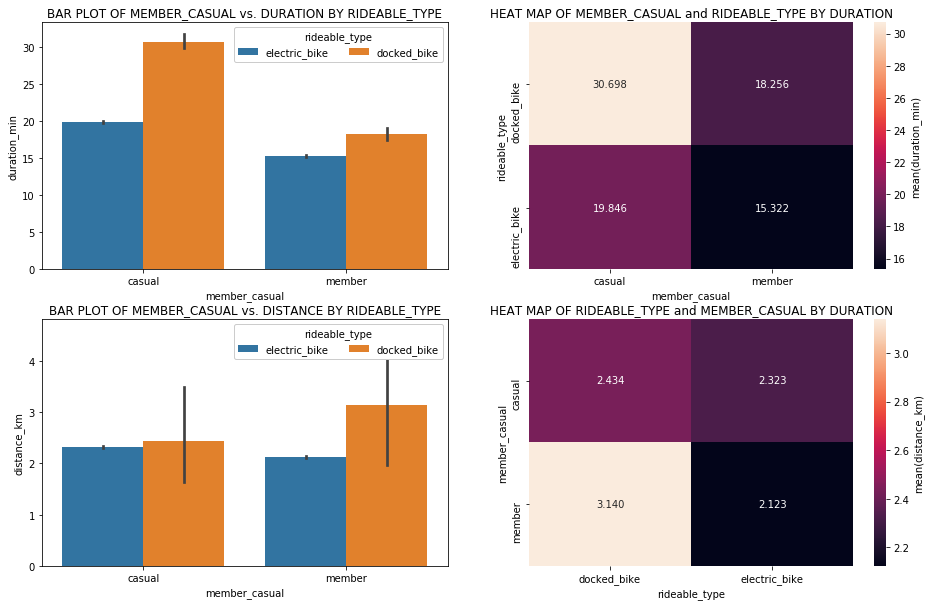

```python
plt.figure(figsize = [16, 10])

plt.subplot(2,2,1)
ax = sb.barplot(data = ride_bike, x = 'member_casual', y = 'duration_min', hue = 'rideable_type');
ax.legend(loc = 1, ncol = 2, framealpha = 1, title = 'rideable_type');
plt.title('BAR PLOT OF MEMBER_CASUAL vs. DURATION BY RIDEABLE_TYPE');


plt.subplot(2,2,2)
cat_means = ride_bike.groupby(['rideable_type', 'member_casual']).mean()['duration_min']
duration_min_avg = ride_bike['duration_min'].count() / ride_bike['duration_min'].shape[0]
cat_means = cat_means.reset_index(name = 'num_var2_avg')
cat_means = cat_means.pivot(index = 'rideable_type', columns = 'member_casual', values = 'num_var2_avg');
sb.heatmap(cat_means, annot = True, fmt = '.3f', cbar_kws = {'label' : 'mean(duration_min)'})
plt.title('HEAT MAP OF MEMBER_CASUAL and RIDEABLE_TYPE BY DURATION');

plt.subplot(2,2,3)
ax = sb.barplot(data = ride_bike, x = 'member_casual', y = 'distance_km', hue = 'rideable_type')
ax.legend(loc = 1, ncol = 2, framealpha = 1, title = 'rideable_type')
plt.title('BAR PLOT OF MEMBER_CASUAL vs. DISTANCE BY RIDEABLE_TYPE');

plt.subplot(2,2,4)
cat_means = ride_bike.groupby(['member_casual', 'rideable_type']).mean()['distance_km']
duration_min_avg = ride_bike['distance_km'].count() / ride_bike['distance_km'].shape[0]
cat_means = cat_means.reset_index(name = 'num_var2_avg')
cat_means = cat_means.pivot(index = 'member_casual', columns = 'rideable_type', values = 'num_var2_avg');
sb.heatmap(cat_means, annot = True, fmt = '.3f', cbar_kws = {'label' : 'mean(distance_km)'})
plt.title('HEAT MAP OF RIDEABLE_TYPE and MEMBER_CASUAL BY DURATION');
```

> `We onserve that not exists correlatin between customer type or bike type with distance ir duration of bike rides, but we would tell that is obvius tht there are more casual customers than suscribers and more electrical bikes than docked bikes.`

### Talk about some of the relationships you observed in this part of the investigation. Were there features that strengthened each other in terms of looking at your feature(s) of interest?

We don't have correlation between the duration or distance based on customer type or bike type.

### Were there any interesting or surprising interactions between features?

Surprisingly we can tell that the maximum distances traveled are around the durations of travel 30 minutes instead longer durations of the trips. We have some but very few almost exceptional, which is actually normal because there is always some person who goes outside the norm.

The rush hour with the highest number of services is 17 pm and the most intense days on Saturday and Sunday.

Finally we have a greater number of casual customers instead of subscribed and also in the fleet of bicycles we have a greater number of electric bikes instead of docked bikes but proportion of use is not related to the type of customer.